# Building your first Stan model. Seaice example

This is an example extended and modified from [OUR Coding Club](https://github.com/ourcodingclub/CC-Stan-intro). Data from [National Snow and Ice Data Center](https://nsidc.org/)

```r
ice <- read.csv("data/seaice.csv", stringsAsFactors = FALSE)
```

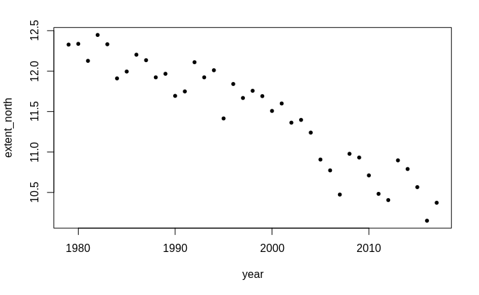

```r
plot(extent_north ~ year, data=ice, pch=20)
```

```r
lm_north <- lm(extent_north ~ year, data=ice)
summary(lm_north)
```

```
Call:
lm(formula = extent_north ~ year, data = ice)

Residuals:
     Min       1Q   Median       3Q      Max
-0.49925 -0.17713  0.04898  0.16923  0.32829

Coefficients:
              Estimate Std. Error t value Pr(>|t|)
(Intercept) 120.503036   6.267203   19.23   <2e-16 ***
year         -0.054574   0.003137  -17.40   <2e-16 ***
---
Signif. codes:  0 ‘***’ 0.001 ‘**’ 0.01 ‘*’ 0.05 ‘.’ 0.1 ‘ ’ 1

Residual standard error: 0.2205 on 37 degrees of freedom
Multiple R-squared:  0.8911,    Adjusted R-squared:  0.8881
F-statistic: 302.7 on 1 and 37 DF,  p-value: < 2.2e-16
```

We can add linear model to the plot by throwing it into `abline()`

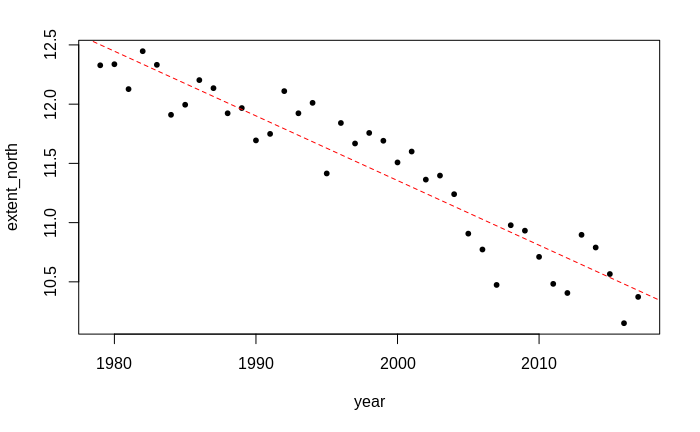

```r
plot(extent_north ~ year, data=ice, pch=20)
abline(lm_north, col="red", lty=2)
```

So the equation of our linear model is
$$y=\alpha+\beta x+\sigma$$
. We’re trying to estimate change of ice cap from the beginning of observations in 1978, so lets make sure the data reflects that.

```r
ice$year_n <- ice$year - 1978
```

The linear model we are interested in is

```r
lm_north1 <- lm(extent_north ~ year_n, data=ice)

lm_north1_summary <- broom::tidy(lm_north1)
knitr::kable(lm_north1_summary)
```

| term | estimate | std.error | statistic | p.value |
| --- | --- | --- | --- | --- |
| (Intercept) | 12.5558880 | 0.0719846 | 174.42476 | 0 |
| year_n | -0.0545739 | 0.0031367 | -17.39857 | 0 |

Let’s collect data for Stan

```r
stan_data <- with(ice, list(N=length(year_n),
                            y=extent_north,
                            x=year_n))
stan_data
```

```
$N
[1] 39

$y
 [1] 12.328 12.337 12.127 12.447 12.332 11.910 11.995 12.203 12.135 11.923 11.967 11.694 11.749 12.110 11.923 12.011
[17] 11.415 11.841 11.668 11.757 11.691 11.508 11.600 11.363 11.397 11.240 10.907 10.773 10.474 10.978 10.932 10.711
[33] 10.483 10.406 10.897 10.790 10.566 10.151 10.373

$x
 [1]  1  2  3  4  5  6  7  8  9 10 11 12 13 14 15 16 17 18 19 20 21 22 23 24 25 26 27 28 29 30 31 32 33 34 35 36 37 38
[39] 39
```

```r
# compile model
library(rstan)
options(mc.cores = floor(parallel::detectCores()/2))
```

Let’s compose simple Stan model for linear regression. You can pass the options to a `stan_model` chunk within `engine.opts` list. [Defaults](https://mc-stan.org/rstan/reference/stan_model.html) for `rstan::stan_model()` are reasonably good so in most instances you wouldnt need that.

```stan
// Names of data elements should match incoming list
data {
 int <lower = 1> N; // Sample size
 vector[N] x; // Predictor. Note, no type
 vector[N] y; // Outcome
}

parameters {
 real alpha; // Intercept
 real beta; // Slope (regression coefficients)
 real <lower = 0> sigma; // positive Error SD
}

// priors are not specified. Implicit U(-Inf,Inf)
model {
 y ~ normal(alpha + x * beta , sigma);
}

generated quantities {
} // The posterior predictive distribution will go here
```

```r
ice_fit <- sampling(ice_stan_model, data=stan_data, iter=1000, chains=4)
```

```
starting worker pid=32206 on localhost:11289 at 11:37:34.635
starting worker pid=32228 on localhost:11289 at 11:37:35.072
starting worker pid=32249 on localhost:11289 at 11:37:35.514
starting worker pid=32270 on localhost:11289 at 11:37:35.861
```

```r
ice_fit
```

```
Inference for Stan model: stan-71bc6f948cba.
4 chains, each with iter=1000; warmup=500; thin=1;
post-warmup draws per chain=500, total post-warmup draws=2000.

       mean se_mean   sd  2.5%   25%   50%   75% 97.5% n_eff Rhat
alpha 12.55    0.00 0.08 12.40 12.50 12.55 12.60 12.69   813 1.00
beta  -0.05    0.00 0.00 -0.06 -0.06 -0.05 -0.05 -0.05   921 1.00
sigma  0.23    0.00 0.03  0.18  0.21  0.23  0.25  0.29   757 1.00
lp__  37.39    0.06 1.31 33.97 36.82 37.71 38.37 38.85   511 1.01

Samples were drawn using NUTS(diag_e) at Fri May 29 11:37:41 2020.
For each parameter, n_eff is a crude measure of effective sample size,
and Rhat is the potential scale reduction factor on split chains (at
convergence, Rhat=1).
```

Let’s extract the parameters and explore the posterior

```r
ice_posterior <- extract(ice_fit)
str(ice_posterior)
```

```
List of 4
 $ alpha: num [1:2000(1d)] 12.4 12.6 12.6 12.5 12.6 ...
  ..- attr(*, "dimnames")=List of 1
  .. ..$ iterations: NULL
 $ beta : num [1:2000(1d)] -0.053 -0.0564 -0.0537 -0.0513 -0.0539 ...
  ..- attr(*, "dimnames")=List of 1
  .. ..$ iterations: NULL
 $ sigma: num [1:2000(1d)] 0.248 0.249 0.223 0.22 0.232 ...
  ..- attr(*, "dimnames")=List of 1
  .. ..$ iterations: NULL
 $ lp__ : num [1:2000(1d)] 36.1 38 38.5 38.3 38.6 ...
  ..- attr(*, "dimnames")=List of 1
  .. ..$ iterations: NULL
```

Spagetti plot in base R!

```r
plot(extent_north ~ year_n, data=ice, pch=20)

idx <- sample(seq_along(ice_posterior$alpha), 500, replace = FALSE)
for (i in idx)
        abline(ice_posterior$alpha[i], ice_posterior$beta[i], col=scales::alpha("gray50", 0.1), lty=1)
```

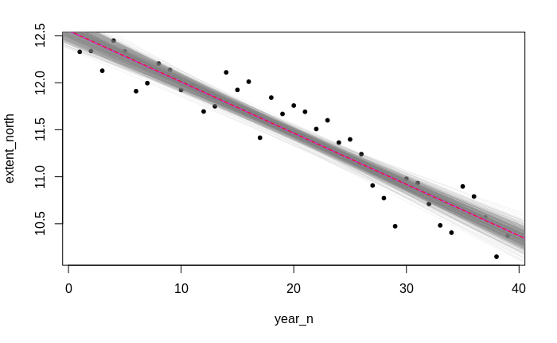

```r
abline(mean(ice_posterior$alpha), mean(ice_posterior$beta), col="magenta")
abline(lm_north1, col = "red", lty = 2)
```

## Changing priors

Let’s try somewhat informative priors to inform our sampler. Recall that the our intercept was around 12.5 and slope -0.05. Lets put something bogus.

```stan
// Stan model for simple linear regression

data {
 int <lower = 1> N; // Sample size
 vector[N] x; // Predictor
 vector[N] y; // Outcome
}

parameters {
 real alpha; // Intercept
 real beta; // Slope (regression coefficients)
 real <lower = 0> sigma; // Error SD
}

model {
 alpha ~ normal(10, 0.1);
 beta ~ normal(1, 0.1);
 y ~ normal(alpha + x * beta , sigma);
}
// saving for later
generated quantities {
}
```

Now Stan has compiled a model for us and put into a variable, so we can start sampling.

```r
ice_fit_ip <- sampling(ice_stan_model_ip, data = stan_data, iter = 1000, chains = 4)
```

```
starting worker pid=32364 on localhost:11289 at 11:42:20.320
starting worker pid=32385 on localhost:11289 at 11:42:20.804
starting worker pid=32406 on localhost:11289 at 11:42:21.307
starting worker pid=32427 on localhost:11289 at 11:42:21.724
```

```r
ice_fit_ip
```

```
Inference for Stan model: stan-71bc7aad535a.
4 chains, each with iter=1000; warmup=500; thin=1;
post-warmup draws per chain=500, total post-warmup draws=2000.

        mean se_mean   sd   2.5%    25%    50%    75%  97.5% n_eff Rhat
alpha  10.11    0.00 0.10   9.92  10.04  10.10  10.17  10.30  1278 1.00
beta    0.05    0.00 0.01   0.03   0.04   0.05   0.05   0.07  1205 1.00
sigma   1.31    0.01 0.18   1.02   1.18   1.29   1.41   1.70  1170 1.00
lp__  -75.07    0.06 1.27 -78.33 -75.62 -74.76 -74.15 -73.63   524 1.01

Samples were drawn using NUTS(diag_e) at Fri May 29 11:42:27 2020.
For each parameter, n_eff is a crude measure of effective sample size,
and Rhat is the potential scale reduction factor on split chains (at
convergence, Rhat=1).
```

The model has converged.

> ‘Anything over an `n_eff` of 100 is usually “fine”’ - Bob Carpenter

```r
ice_posterior_ip <- extract(ice_fit_ip)

# old lines
plot(extent_north ~ year_n, data=ice)

idx <- sample(seq_along(ice_posterior_ip$alpha), 500, replace = FALSE)
# new line
for (i in idx)
        abline(ice_posterior_ip$alpha[i], ice_posterior_ip$beta[i], col=scales::alpha("gray50", 0.1), lty=1)
```

```r
abline(mean(ice_posterior_ip$alpha), mean(ice_posterior_ip$beta), col="forestgreen")
abline(mean(ice_posterior$alpha), mean(ice_posterior$beta), col="magenta")
```

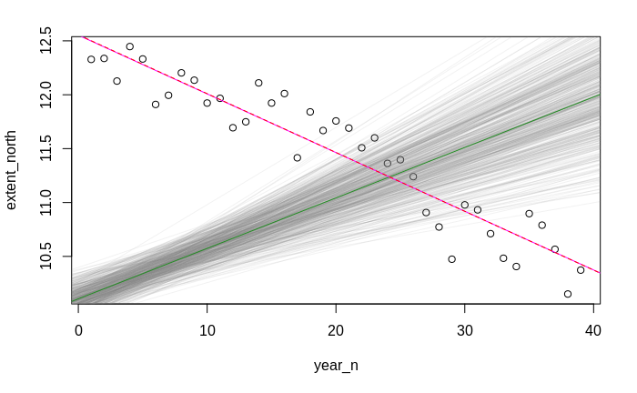

```r
abline(lm_north1, col = "red", lty = 2)
```

So, what happened? If your priors are too narrow but off, you are going to get some strange fits. Let’s examing traceplots.

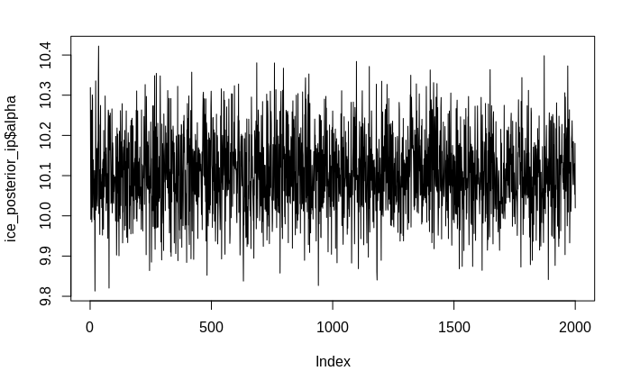

```r
plot(ice_posterior_ip$alpha, type = "l")
```

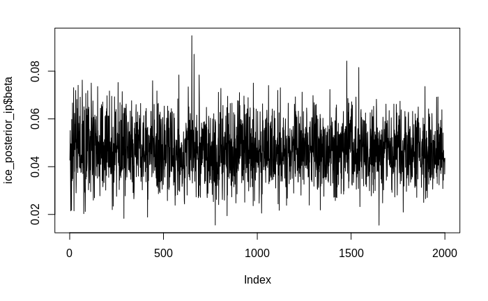

```r
plot(ice_posterior_ip$beta, type = "l")
```

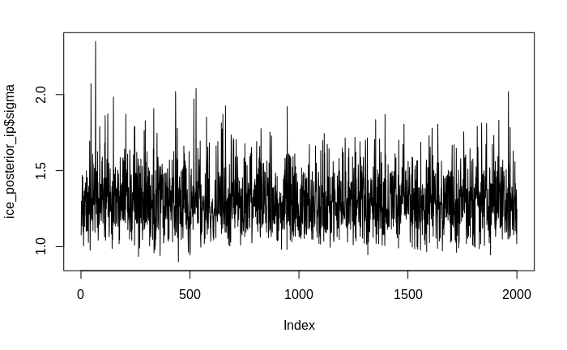

```r
plot(ice_posterior_ip$sigma, type = "l")
```

Poor convergence can happen when you use too few iterations. Re-sampling our original (non IP) analysis. Note single function `traceplot` that shows all parameters

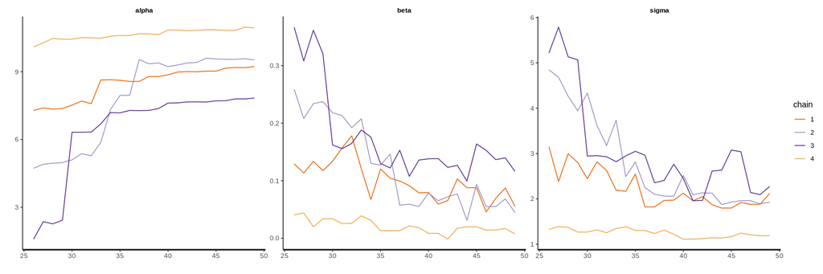

## Summary of parameters

```r
par(mfrow = c(1,3))

plot(density(ice_posterior$alpha), main = "Alpha")
abline(v = lm_north1_summary$estimate[1], col = "blue", lty = 2)
```

```r
plot(density(ice_posterior$beta), main = "Beta")
abline(v = lm_north1_summary$estimate[2], col = "blue", lty = 2)
```

```r
plot(density(ice_posterior$sigma), main = "Sigma")
abline(v = sigma(lm_north1), col = 4, lty = 2)
```

[figure not shown]

```r
par(mfrow = c(1,1))
```

Same using built-in function

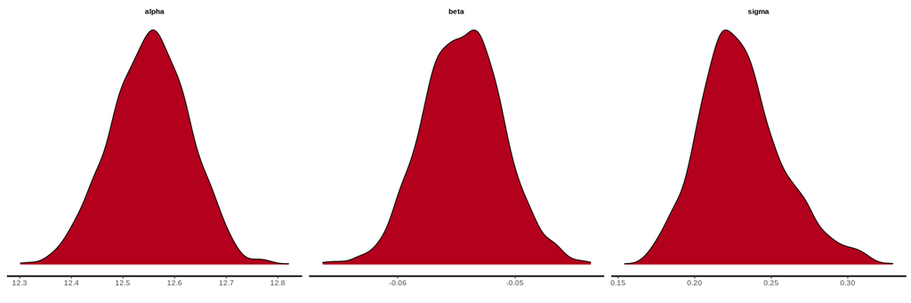

```r
stan_dens(ice_fit)
```

```r
#stan_hist(ice_fit_ip_bad)
```

## Posterior predictive checks

For prediction and as another form of model diagnostic, Stan can use **random number generators to generate predicted values for each data point**, at each iteration. We generate these using the `generated quantities` block. Note that there’s no vectorization in GQ block.

```stan
data {
 int <lower = 1> N; // Sample size
 vector[N] x; // Predictor
 vector[N] y; // Outcome
}

parameters {
 real alpha; // Intercept
 real beta; // Slope (regression coefficients)
 real <lower = 0> sigma; // Error SD
}

model {
 y ~ normal(x * beta + alpha, sigma);
}

generated quantities {
 real y_rep[N];

 for (n in 1:N)
   y_rep[n] = normal_rng(x[n] * beta + alpha, sigma);
}
```

```r
ice_fit_pp <- sampling(ice_stan_model_pp, data = stan_data, iter=1000, chains=4)
```

```
starting worker pid=32697 on localhost:11289 at 11:49:30.478
starting worker pid=32718 on localhost:11289 at 11:49:30.949
starting worker pid=32739 on localhost:11289 at 11:49:31.445
starting worker pid=314 on localhost:11289 at 11:49:31.831
```

```r
ice_fit_pp
```

```
Inference for Stan model: stan-71bc4a86a2fb.
4 chains, each with iter=1000; warmup=500; thin=1;
post-warmup draws per chain=500, total post-warmup draws=2000.

           mean se_mean   sd  2.5%   25%   50%   75% 97.5% n_eff Rhat
alpha     12.56    0.00 0.07 12.42 12.51 12.56 12.60 12.69   717    1
beta      -0.05    0.00 0.00 -0.06 -0.06 -0.05 -0.05 -0.05   819    1
sigma      0.23    0.00 0.03  0.18  0.21  0.22  0.24  0.29   829    1
y_rep[1]  12.50    0.01 0.24 12.03 12.34 12.51 12.66 12.96  1859    1
y_rep[2]  12.45    0.01 0.24 11.98 12.29 12.45 12.60 12.92  1817    1
y_rep[3]  12.39    0.01 0.24 11.91 12.24 12.40 12.55 12.86  2065    1
y_rep[4]  12.33    0.01 0.23 11.86 12.18 12.33 12.49 12.79  1972    1
y_rep[5]  12.28    0.01 0.24 11.82 12.13 12.28 12.44 12.74  1640    1
y_rep[6]  12.22    0.01 0.23 11.78 12.08 12.22 12.37 12.67  1915    1
y_rep[7]  12.18    0.01 0.23 11.71 12.03 12.18 12.34 12.63  1589    1
y_rep[8]  12.12    0.01 0.23 11.66 11.97 12.12 12.28 12.58  1941    1
y_rep[9]  12.07    0.01 0.24 11.62 11.91 12.07 12.21 12.53  1948    1
y_rep[10] 12.01    0.01 0.23 11.56 11.86 12.01 12.16 12.46  1861    1
y_rep[11] 11.97    0.01 0.23 11.51 11.81 11.97 12.13 12.44  1883    1
y_rep[12] 11.90    0.01 0.24 11.42 11.74 11.89 12.06 12.38  2022    1
y_rep[13] 11.84    0.00 0.23 11.39 11.70 11.83 11.98 12.30  2081    1
y_rep[14] 11.80    0.01 0.23 11.35 11.65 11.79 11.95 12.25  2082    1
y_rep[15] 11.74    0.01 0.23 11.29 11.59 11.74 11.91 12.18  1878    1
y_rep[16] 11.68    0.01 0.22 11.24 11.54 11.68 11.83 12.13  1888    1
y_rep[17] 11.63    0.01 0.23 11.18 11.47 11.63 11.79 12.08  1965    1
y_rep[18] 11.57    0.00 0.23 11.13 11.42 11.57 11.72 12.03  2086    1
y_rep[19] 11.52    0.01 0.24 11.05 11.37 11.52 11.68 12.00  1745    1
y_rep[20] 11.46    0.01 0.23 11.01 11.31 11.47 11.62 11.92  2018    1
y_rep[21] 11.41    0.01 0.24 10.97 11.26 11.41 11.56 11.90  1939    1
y_rep[22] 11.35    0.01 0.23 10.89 11.20 11.36 11.51 11.82  1921    1
y_rep[23] 11.30    0.01 0.23 10.84 11.14 11.30 11.46 11.73  2103    1
y_rep[24] 11.25    0.01 0.23 10.79 11.10 11.25 11.41 11.70  1917    1
y_rep[25] 11.20    0.01 0.23 10.75 11.05 11.20 11.35 11.65  2104    1
y_rep[26] 11.14    0.01 0.23 10.69 10.99 11.14 11.30 11.60  1997    1
y_rep[27] 11.09    0.01 0.23 10.62 10.93 11.09 11.25 11.54  1947    1
y_rep[28] 11.04    0.01 0.23 10.58 10.89 11.04 11.19 11.48  1987    1
y_rep[29] 10.97    0.01 0.24 10.51 10.81 10.97 11.13 11.44  2098    1
y_rep[30] 10.93    0.01 0.24 10.45 10.77 10.93 11.08 11.38  1917    1
y_rep[31] 10.85    0.01 0.23 10.39 10.71 10.85 11.00 11.31  1903    1
y_rep[32] 10.81    0.01 0.24 10.34 10.66 10.80 10.96 11.28  2006    1
y_rep[33] 10.76    0.01 0.24 10.28 10.60 10.76 10.91 11.22  1979    1
y_rep[34] 10.69    0.01 0.24 10.24 10.53 10.68 10.85 11.16  1876    1
y_rep[35] 10.64    0.01 0.24 10.18 10.49 10.64 10.80 11.10  1990    1
y_rep[36] 10.58    0.01 0.25 10.10 10.42 10.58 10.75 11.05  2034    1
y_rep[37] 10.54    0.01 0.24 10.07 10.38 10.53 10.70 11.02  1919    1
y_rep[38] 10.49    0.01 0.23 10.03 10.33 10.48 10.64 10.95  1866    1
y_rep[39] 10.43    0.01 0.24  9.95 10.28 10.43 10.58 10.90  2024    1
lp__      37.47    0.06 1.24 34.25 36.89 37.78 38.34 38.86   508    1

Samples were drawn using NUTS(diag_e) at Fri May 29 11:49:38 2020.
For each parameter, n_eff is a crude measure of effective sample size,
and Rhat is the potential scale reduction factor on split chains (at
convergence, Rhat=1).
```

We can extract `y_rep` with specialized `as.matrix` method. Each row here is a single postenrior estimate from the model

```r
y_rep <- as.matrix(ice_fit_pp, pars="y_rep")
dim(y_rep)
```

```
[1] 2000   39
```

Compare the density of our `extent_north` to some 200 draws from posterior

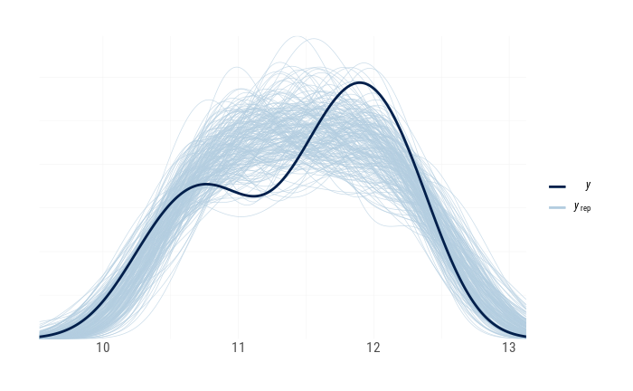

```r
library(bayesplot)
ggplot2::theme_set(hrbrthemes::theme_ipsum_rc(grid_col = "gray95"))

ppc_dens_overlay(ice$extent_north, y_rep[1:200,])
```

We can also compare summary statistics. You can choose any summary statistics function, even your own. See `bayesplot` docs for details.

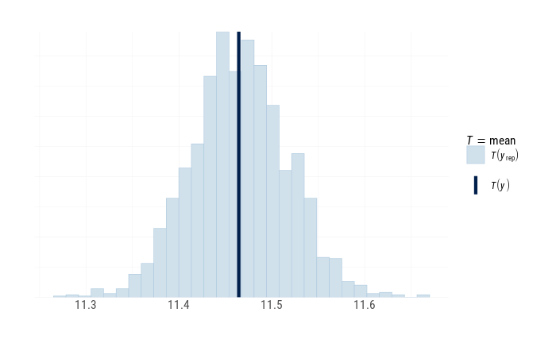

```r
ppc_stat(y = ice$extent_north, yrep = y_rep, stat = "mean")
```

Here’s a comparison of mean posterior prediction **per datapoint** vs the observed value for each datapoint (default line is 1:1)

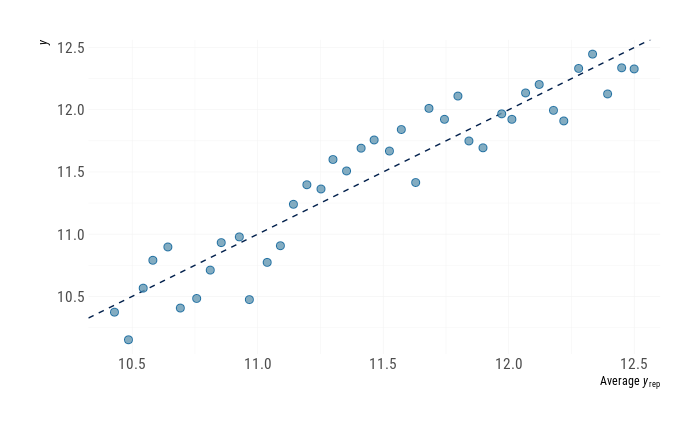

```r
ppc_scatter_avg(y = ice$extent_north, yrep = y_rep)
```

## Some useful tips for fitting Stan models

### DRY

Avoid repeated operations

```stan
// 1/alpha is repeated
  for(n in 1:N)
    y[n]~ exponential(1/alpha * x[n]);
```

### Vectorization

Use it where possible. It is cleaner (and faster)

```stan
// not vectorized
  for(n in 1:N)
     y[n]~ normal(beta0 + beta1 * x[n], sigma);

//vectorized
  y ~ normal(beta0 + beta1 * x, sigma);
```

### Priors

The more informative the better (think better initial conditions). Use experts and/or MLE to get initial estimates.

### Parallization

You can run multiple chains if you have multiplecores, but each chain is still serial

### Look under the hood

Check our `shredder` package

```r
# or filter by condition
ice_fit_pp %>%
        stan_select(alpha, beta, sigma) %>%
        stan_filter(alpha > 12.55)
```

```
Inference for Stan model: stan-71bc4a86a2fb.
4 chains, each with iter=736; warmup=500; thin=1;
post-warmup draws per chain=236, total post-warmup draws=944.

       mean se_mean   sd  2.5%   25%   50%   75% 97.5% n_eff Rhat
alpha 12.61       0 0.04 12.55 12.57 12.60 12.64 12.72   418 1.01
beta  -0.06       0 0.00 -0.06 -0.06 -0.06 -0.05 -0.05   565 1.01
sigma  0.22       0 0.03  0.18  0.21  0.22  0.24  0.28   509 1.00

Samples were drawn using  at Fri May 29 11:49:38 2020.
For each parameter, n_eff is a crude measure of effective sample size,
and Rhat is the potential scale reduction factor on split chains (at
convergence, Rhat=1).
```